# Caso Práctico 05: Colgate vs Colgate

Isabel Afán de Ribera

23 noviembre 2020

# 1. Resumen Ejecutivo

Este informe explica la utilidad de la metodología de las series temporales y el análisis de intervención en la evaluación del impacto que las iniciativas de las empresas, los competidores o terceros pueden suponer en el mercado. En concreto, se va a analizar un caso de negocio real de competencia entre la crema dental Colgate de Colgate-Palmolive y la crema dental Crest de Procter y Gamble.

# 2. Objetivo

El objetivo de este análisis es predecir la cuota de mercado de las primeras 16 semanas del año 1963 para las marcas Colgate y Crest. Para ello se realizará una estimación de series temporales mediante el modelo ARIMA, una detección de atípicos/outlier, un modelo de interveción y, por último, un modelo de función de tranferencia entre las dos cuotas.

# 3. Desarrollo

Colgate, empresa estadounidense fundada en 1806, dedicada a la producción y comercialización de productos de cuidado personal disfrutaba de de un liderazgo de mercado con una participación cercana al 50% hasta 1956, momento en el que Procter y Gamble introduce Crest en el mercado estadounidense.

Durante los siguientes 4 años, Colgate siguió siendo un competidor dominante y Crest solo logró una participación de mercado relativamente modesta pero estable del 15%. Sin embargo, el 1 de agosto de 1960, el Consejo de Terapéutica Dental de la American Dental Association (ADA) aprobó a Crest como una “ayuda importante en cualquier programa de higiene dental”. Este impulso fue aprovechado por Procter y Gamble con una potente campaña de publicidad lo que llevo a Crest a dar un salto en el mercado acaparando cuota en detrimento de Colgate.

## 3.1. Evolución cuota de mercado Crest y Colgate

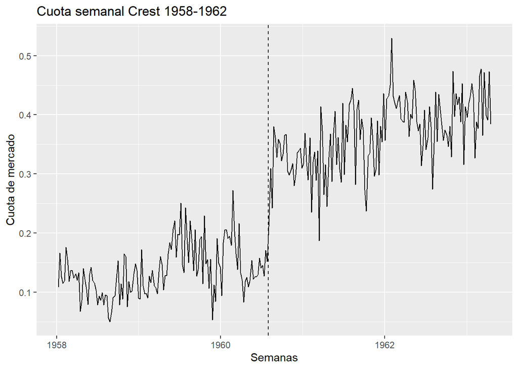

En este gráfico relativo a la cuota de mercado de la marca Crest se observa una serie temporal con tendencia creciente con un impulso en 1960, momento en el que se produce la aprobación por parte de la ADA de Crest como una “ayuda importante en cualquier programa de higiene dental”. Este hecho unido al fortalecimiento de la campaña publicitaria de Procter y Gamble activó la cuota de mercado de Crest en detrimento de Colgate.

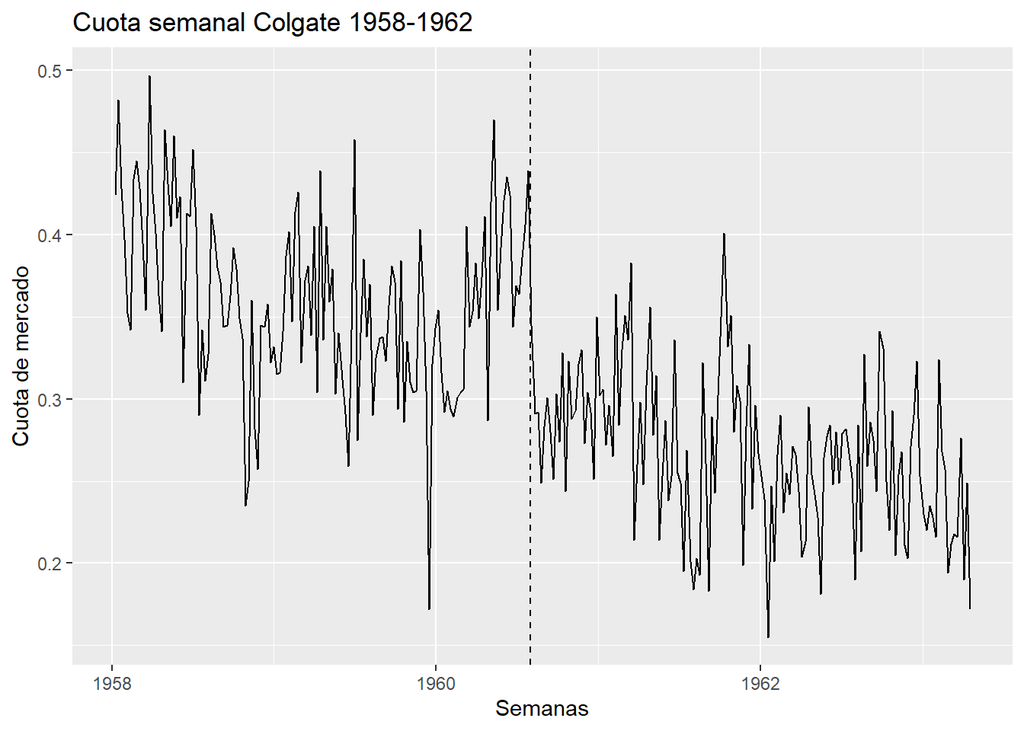

Por el contrario, si se observa el gráfico sobre la cuota de mercado de Colgate puede apreciarse una evolución decreciente producia por un escalón de caida en 1960. Hasta este momento, la marca habia disfrutado de liderazgo en la cuota de mercado (50%) pero con este hecho Crest empieza a superar a Colgate.

## 3.2. Modelo Arima

Teniendo en cuenta que contamos con información sobre dos series temporales no estacionarias es necesario implantar un modelo que las convierta en estacionarias, pues de esta manera resulta más fácil realizar una predicción. Si se comportaba de una manera en el pasado (con una determinada media y varianza), puede suponerse que se seguirá comportando de la misma forma en el futuro

Para ello se van a dividir los datos de cuota de mercado en dos subconjuntos, uno para el `training` donde se incluirá el intervalo de fechas de enero de 1958 hasta diciembre de 1962. Y otro para `test` donde se incluirá la información de 1963 para predecir las primeras 16 semanas.

El modelo automático ARIMA nos ha permitido obtener una serie temporal estacionaria con un modelo (0, 1, 1) para ambas marcas. Además, se han analizado los residuos de forma gráfica y se ha realizado la prueba *box-Ljung Test* para comprobar la ausencia de autocorrelación y que se da ruido blanco.

### 3.2.1. Crest

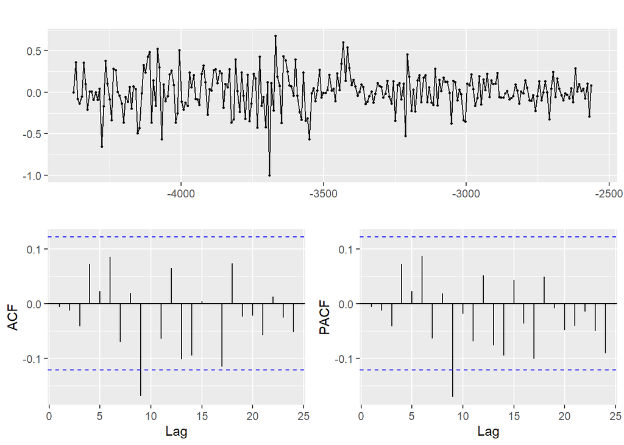

Además, todos los p-value obtenidos para distintos retardos y grados de libertad son superiores a 0.05, por tanto, se vuelve a comprobar que las autocorrelaciones de los residuos son ruido blanco (ausencia de autocorrelación).

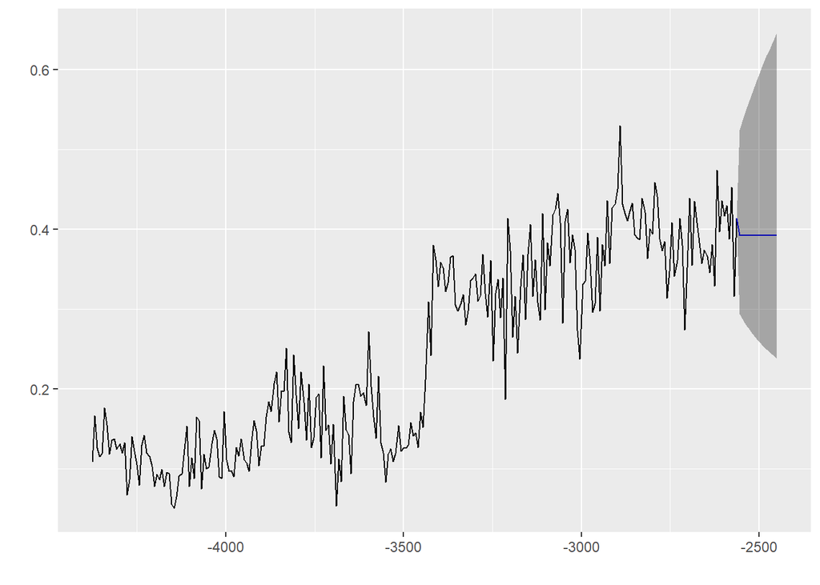

Si comparamos las predicciones del modelo ARIMA con la cuota real que finalmente consiguió Crest puede decirse que el modelo estima la cuota a la baja pues a pesar de acercarse bastante a la realidad Crest consigió durante varias de estas semanas superar el 0.4 de cuota. Además, si se observa el gráfico se ve una predicción plana, lo cual nos lleva a pensar que no se trata de una buena predicción.

### 3.2.2. Colgate

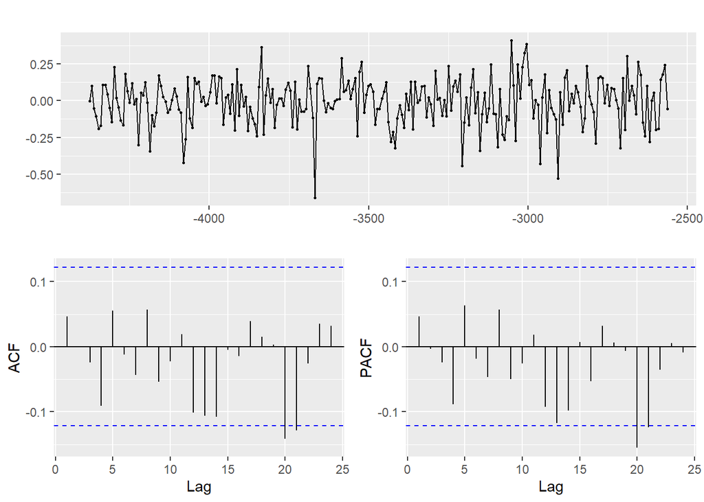

Además, todos los p-value obtenidos para distintos retardos y grados de libertad son superiores a 0.05, por tanto, se vuelve a comprobar que las autocorrelaciones de los residuos son ruido blanco (ausencia de autocorrelación). Los errores del presente no dependen de los errores del pasado.

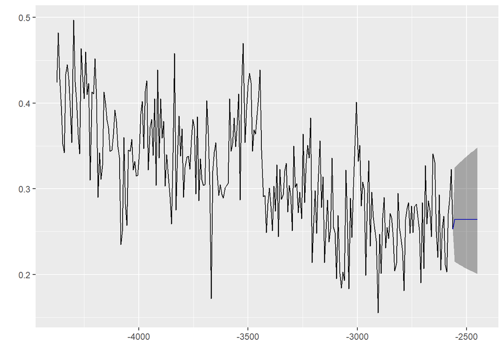

En la predicción del modelo ARIMA para Colgate ocurre algo muy parecido a Crest, la predicción de cuota de mercado es completamente plana, estima la misma cuota para todas las semanas algo que en la realidad es imposible que ocurra y, así puede comprobarse viendo los datos reales sobre la cuota que Colgate obtuvo en esas 16 semanas, la cual se sitúa entre el 0.172 y 0.324.

### 3.2.3. Detección de outliers

Se han detectado dos outliers en Crest, uno de tipo aditivo en la fila 136 que se corresponde con el 8 de agosto del 60 y otro innovativo en la fila 99 correspondiente a la fecha del 23 noviembre del 59.

Para el caso de Colgate se ha detectado un outlier innovativo en la fila 102 correspondiente a la fecha del 14 de diciembre del 59.

## 3.3. Modelo de intervención

### 3.3.1. ARIMAX Crest

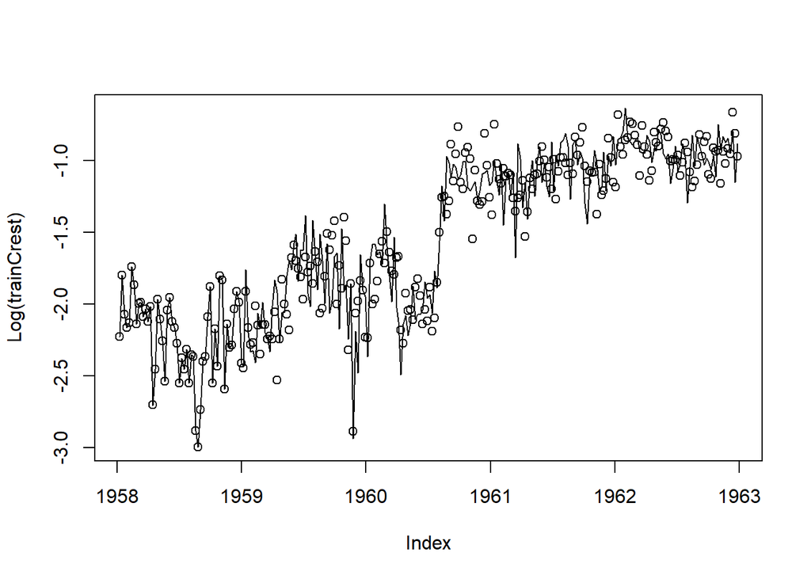

Efecto de la intervención del ADA

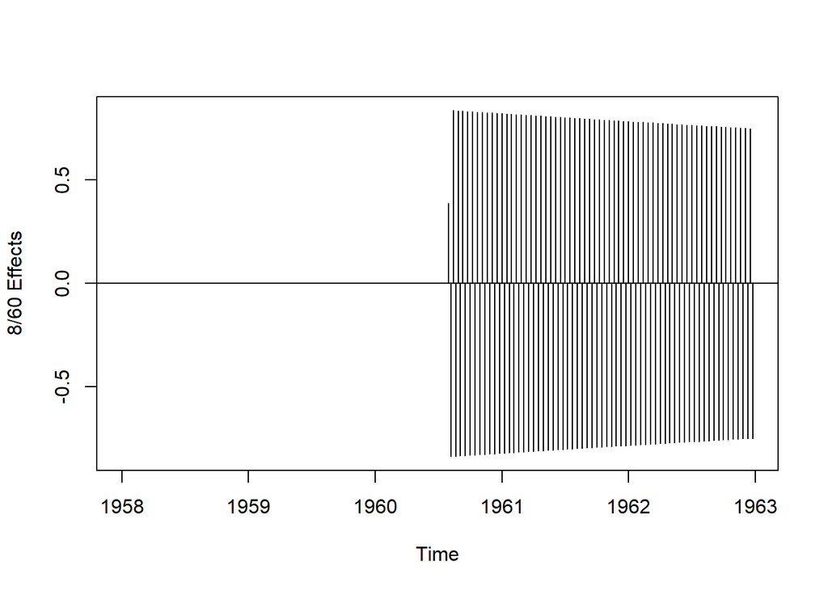

En el caso de Crest la intervención del ADA supone un incremento en su cuota de mercado que se mantiene estable durante los siguientes años.

### 3.3.2. ARIMAX Colgate

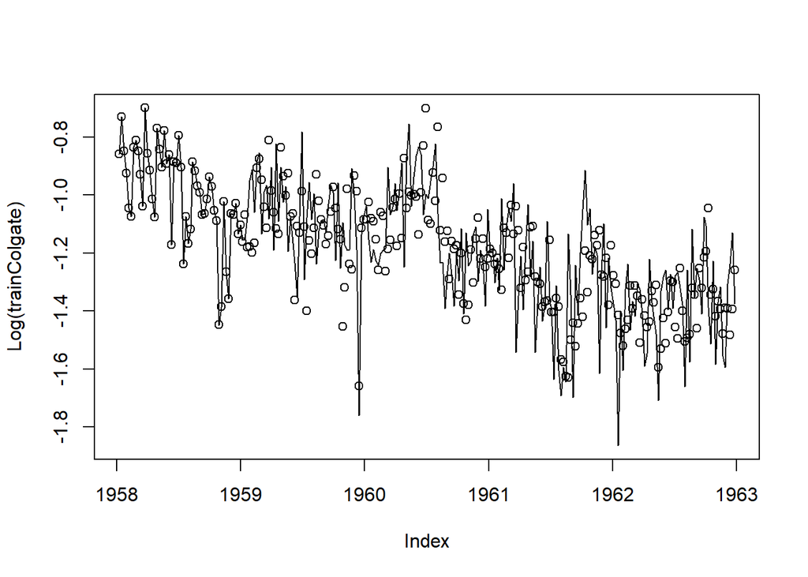

Efecto de la intervención del ADA

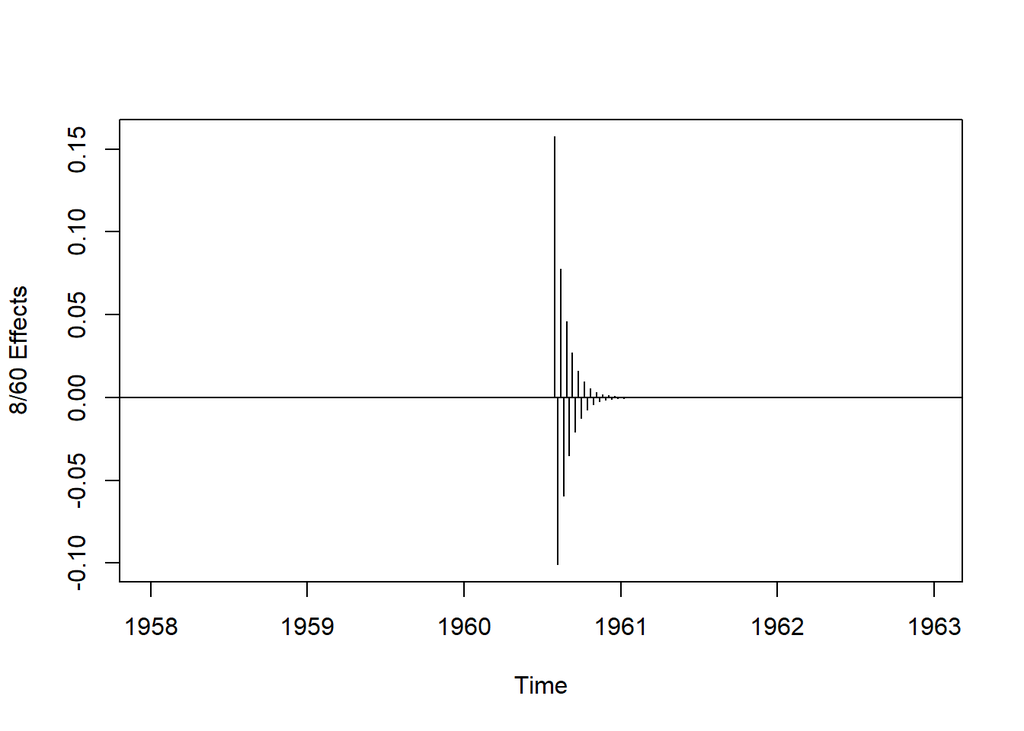

## 3.4. Detección de atípicos/outlier

No se han detectado outliers para Crest.

Tampoco se han detectado outliers para Colgate.

## 3.5. Función de transferencia

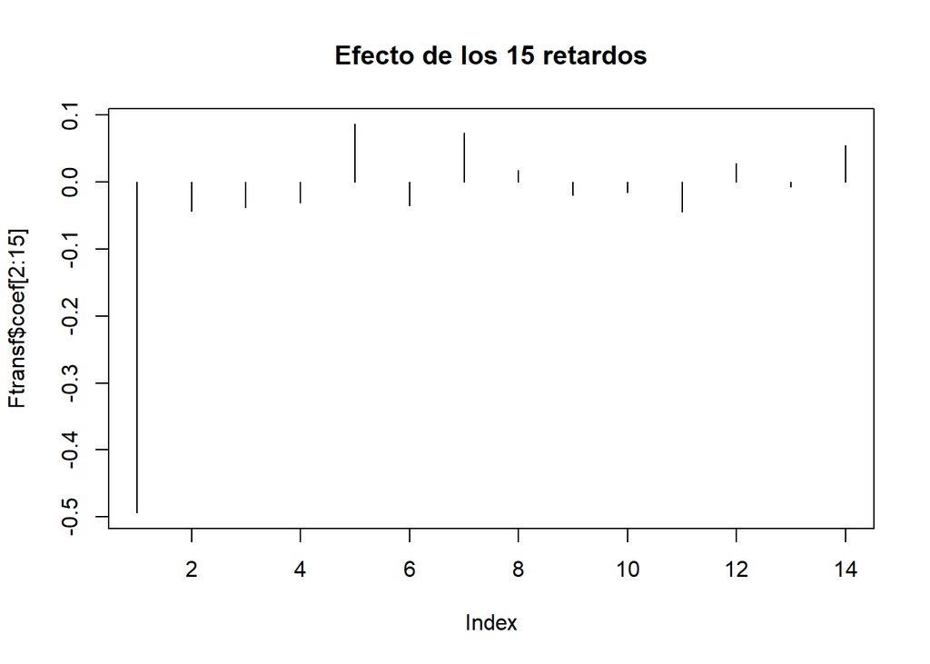

# 4. Conclusiones

De este informe se pueden extraer una serie de conclusiones. En primer lugar, que resulta fundamental la reacción de las compañías ante sucesos del entorno. En este análisis se han visto dos reacciones muy distintas por parte de dos empresas competidoras ante la decisión de un organismo externo. De un lado, la compañía Procter y Gamble supó aprovechar el impulso otorgado por el Consejo de Terapéutica Dental de la American Dental Association a través de una estrategia publicitaria. De otro, Colgate-Palmolive confiada en su fuerte posición en el mercado debería haber adoptado alguna iniciativa como, por ejemplo, la innovación en alguno de sus productos.

En segundo lugar, ha resultado evidente el efecto opuesto que produjó el anuncio de la ADA al tratarse de empresas del mismo sector. Mientras que la cuota de mercado de una subía la otra bajaba llegando Crest a quitarle el liderazgo de mercado que Colgate tenía hasta 1960. Algo que ha sido evidente en la función de transferencia donde los resultados negativos indican que el incremento de las ventas en Crest produjo un efecto negativo en las ventas de Colgate.

Por último, cabe concluir que la apuesta de Procter y Gamble por revitalizar su campaña de marketing aprovechando el apoyo de la ADA ha resultado muy efectiva, la empresa ha sabido tomar ventaja de las circunstancias.

# Referencias

- Aptech (2020) Introduction to the Fundamentals of Time Series Data and Analysis. Disponible en: https://www.aptech.com/blog/introduction-to-the-fundamentals-of-time-series-data-and-analysis/
- Queralt, R.(2020). Series Temporales - Intervención, Función de Transferencia y ARIMAX. Colegio Universitario de Estudios Financieros
- Queralt, R.(2020). Series Temporales - Modelos ARIMA. Colegio Universitario de Estudios Financieros